# Archived Soil Incubations Manuscript Figures

J. Beem-Miller

08 Oct 2020

## Notes

- This workbook is intended to load and prepare the key data for analysis for the archive incubation project.
- This is an updated version of RMD file “./src/arc_inc_data-wrangling_2020-04-20.Rmd” with the explanatory text removed
- all code chunk options are set to “echo = FALSE”; see raw .Rmd file for data wrangling code.

# Methods and materials

*Radiocarbon corrections*

Although differences were small, radiocarbon data for archived samples were first corrected for decay since the year of collection before assessing treatment effects.

Decay correction formula:
$$1000 \cdot \left( (FM \cdot e^{\frac{-year_{sampled} + 1950}{8267}}) - 1 \right)$$

where FM is the fraction modern, and 8267 is the inverse of the product of the natural log of two and the true half life of <sup>14</sup>C (5730 y).

# Results

## Respiration rates

*note that the text below was left because statistics were calculated on the fly*

*Experiment 1 (air-dry + storage treatment)*

Among the air-dry + storage samples, respiration rates were more than twice as high in grassland soils than in forest soils, reaching a maximum of 7.1 mg CO<sub>2</sub> g soil C<sup>-1</sup> d<sup>-1</sup> after 0.7 d, followed by a sharp decline. Mean respiration rates in forest sites peaked at 1.5 mg CO<sub>2</sub> g soil C<sup>-1</sup> d<sup>-1</sup> after 6.9 d, followed by a much more gradual decline than in grassland sites. Control samples responded more weakly and more gradually to rewetting, although as in the treatment samples respiration was greater in grassland soils than in forest soils. Peak respiration rates for control incubations were 1.9 and 0.6 mg CO<sub>2</sub> g soil C<sup>-1</sup> d<sup>-1</sup> after 4.8 d for grassland and forest soils, respectively.

*Experiment 2 (air-dry treatment, 2019 samples)*

Peak respiration rates were not significantly different (p > 0.05) between forest and grassland soils in Experiment 2, peaking at 3.0 and 3.3 mg CO<sub>2</sub> g soil C<sup>-1</sup> d<sup>-1</sup> after 95 h for grassland and forest soils, respectively **(Fig. 1)**.

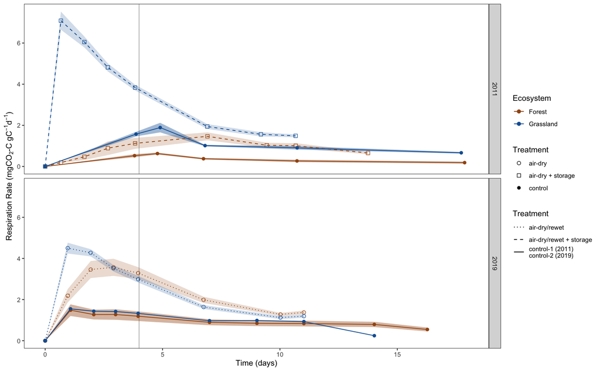

> **Fig. 1. Respiration rates for Experiment 1 (air-dry + storage treatment, 2011) and Experiment 2 (air-dry only treatment, 2019)**

> *Caption:* Top panel shows data from samples collected in 2011 for Experiment 1 (air-dry + storage treatment), bottom panel shows data from samples collected in 2019 for Experiment 2 (air-dry only treatment). Vertical gray line at day 4 demarcates the end of the pre-incubation period and the start of the equilibrium respiration period. Points show measurements and lines show trends in mean respiration rate. Shaded ribbons represent one standard error. The final measurement points for a few samples which took >18 days to reach CO<sub>2</sub> targets are excluded for display reasons; respiration rates for those samples remained flat. Note that headspace CO<sub>2</sub> concentrations for Experiment 1 control samples were only measured once during the pre-incubation period (day 4) in contrast to daily measurements for all other samples. Consequently the respiration rate for those samples is the cumulative average rate over the first 4 d.

*Supplemental respiration rates figures:*

*Experiment 3 (storage duration)*

Grassland soils from the storage duration treatment group responded rapidly to rewetting and reached target CO<sub>2</sub> levels after just 72 h of incubation. Only a single observation was made for the grassland treament samples due to the rapid respiration rates, which peaked at 5.6 mg CO<sub>2</sub> g soil C<sup>-1</sup> d<sup>-1</sup>. The mean peak respiration rate for forest treatment samples was lower and lagged in comparison to the grassland soils, reaching 2.2 mg CO<sub>2</sub> g soil C<sup>-1</sup> d<sup>-1</sup> after 97 h.

Control-3 respiration rates peaked after the pre-incubation period (115 h), at 2.3 mg CO<sub>2</sub> g soil C<sup>-1</sup> d<sup>-1</sup>. Forest control samples were pre-incubated under various conditions, but respiration rates were only measured during the pre-incubation period for two samples from the Sierra Nevada mountains (USA). In general, respiration rates for forest control samples in Experiment 3 were much lower than in the treatment incubations, peaking at 0.6 mg CO<sub>2</sub> g soil C<sup>-1</sup> d<sup>-1</sup> after 120 h.

Preincubation headspace CO<sub>2</sub> concentations were only measured once for the control-1 samples, at the end of the four=day preincubation period. In order to compare the control-1 respiration rates more easily with the air-dry + storage treatment samples, Supplemental Figure 2 shows the air-dry + storage pre-incubation respiration rates plotted as a cumulative average for the preincubation period. However, as can be seen in Figure 1, headspace CO<sub>2</sub> concentration was measured daily for the air-dry + storage samples.

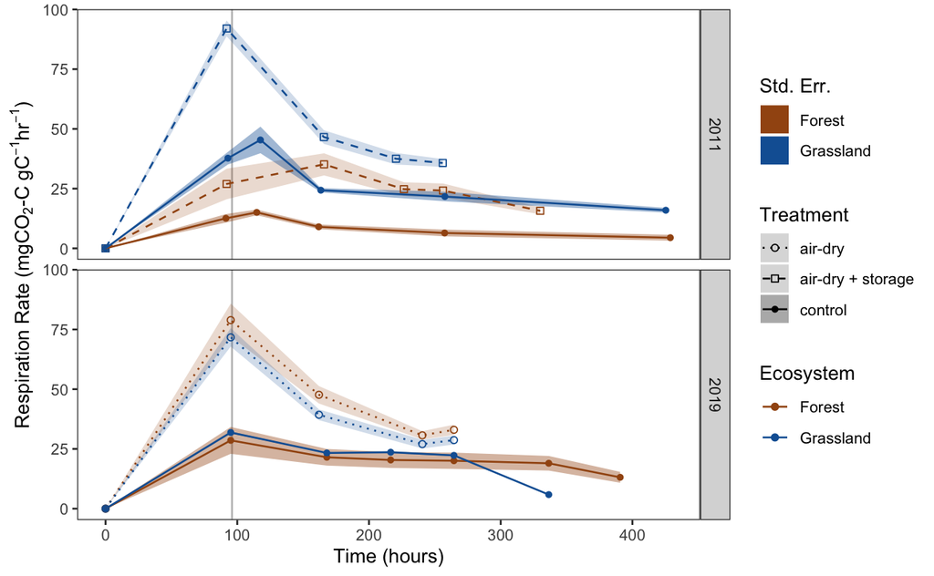

> **Supplemental Fig 2. Respiration rates for Experiment 1 and Experiment 2 shown with all pre-incubation data calculated as cumulative averages**

> *Caption:* CO<sub>2</sub> concentrations for Experiment 1 control samples were only measured once during the pre-incubation period, in contrast to daily measurements for all other samples. Pre-incubation respiration rates are shown here calculated as cumulative averages for the purpose of fair comparison across all treatments.

## Radiocarbon data

[output not shown]

*Pre-incubation versus equilibrium respiration <sup>14</sup>C-CO<sub>2</sub>*

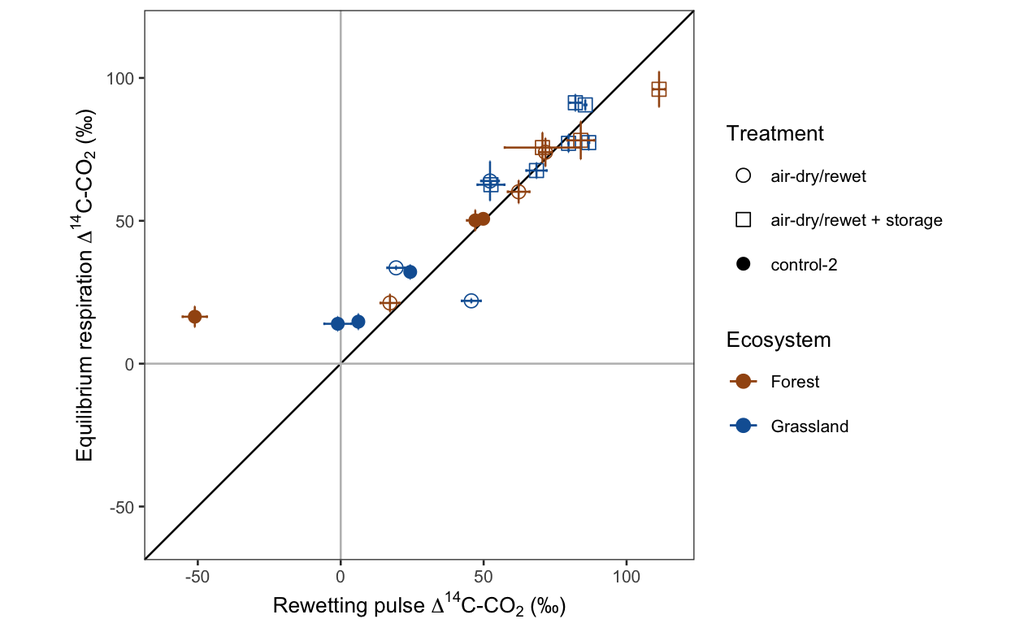

> **Fig. 2. $\Delta$<sup>14</sup>C-CO<sub>2</sub> of the rewetting pulse and the equilibrium respiration period**

> *Caption:* Points are means of laboratory duplicates and error bars are the min and max (except for Experiment 1 control samples, which were not replicated). Note that rewetting pulse $\Delta$<sup>14</sup>C was not measured for control-1 samples; additionally samples from three of the forest plots of the air-dry + storage samples from Experiment 1 failed to accumulate enough CO<sub>2</sub> during the pre-incubation period to measure $\Delta$<sup>14</sup>C. The outlier point with the substantially depleted pre-incubation $\Delta$<sup>14</sup>C is from Experiment 2 (control).

## Treatment effect on $\Delta$<sup>14</sup>C-CO<sub>2</sub> for all samples (Experiments 1, 2, and 3)

[output not shown]

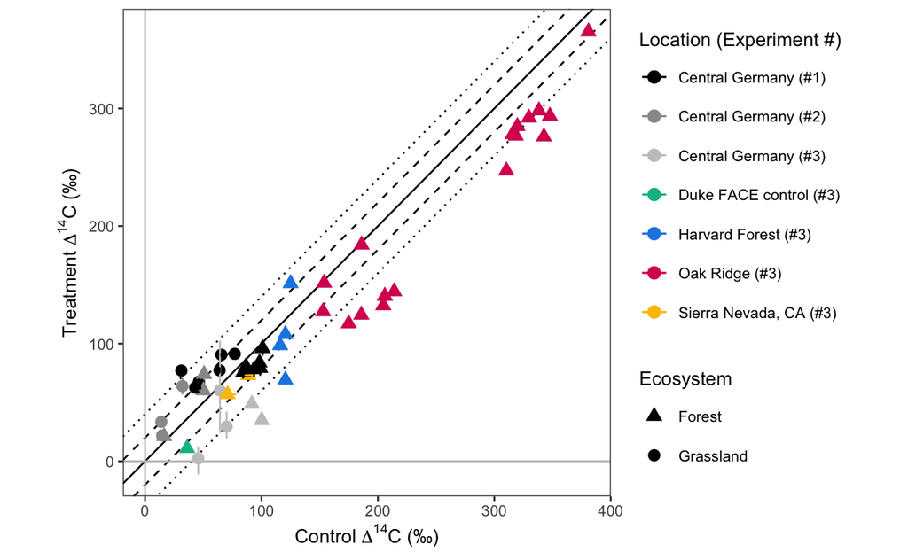

> **Fig. 3. Overall treatment effect on $\Delta$<sup>14</sup>C-CO<sub>2</sub>**

> *Caption:* Points show data from Experiments 1 and 3 (air-dry + storage treatment) and Experiment 2 (air-dry only treatment). Points are the mean of laboratory replicates (for replicated samples); error bars are 2x standard error. Solid line is 1:1. For context, the dashed and dotted lines show differences of ±20‰ and ±$40‰, equivalent to the decline in $\Delta$<sup>14</sup>C in atmospheric CO<sub>2</sub> over 4 and 8 y respectively, during the period of 2000 to 2020 (Graven et al. 2017).

## Storage duration effect on <sup>14</sup>C-CO<sub>2</sub> (Experiment 3)

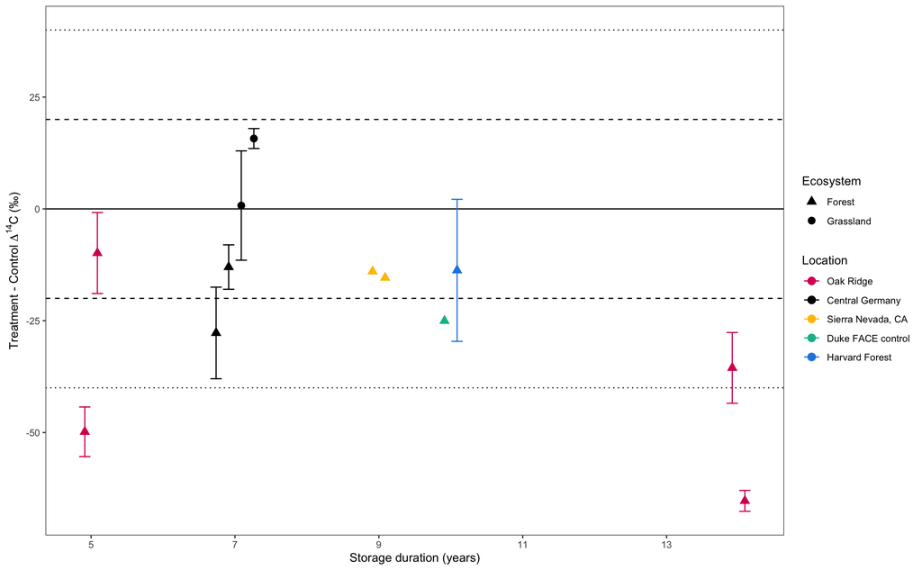

> **Fig. 4. Change in <sup>14</sup>C-CO<sub>2</sub> in relation to storage duration**

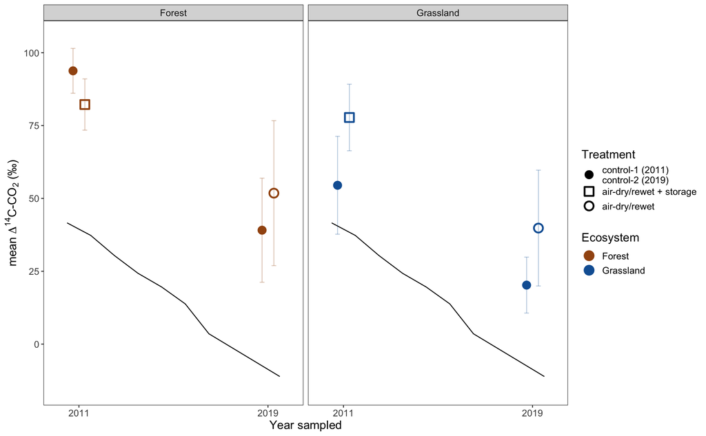

> **Fig 5. Time series of control and treatment $\Delta$<sup>14</sup>C-CO<sub>2</sub> (Experiments 1 and 2)**

> *Caption:* Filled circles show $\Delta$<sup>14</sup>C-CO<sub>2</sub> observed for both control-1 and control-2 samples (2011 and 2019 points, respectively). Open symbols show $\Delta$<sup>14</sup>C-CO<sub>2</sub> observed for treament samples: open squares = air-dry + storage treatment, Experiment 1; open circles = air-dry only treatment, Experiment 2. Points are means and error bars show the pooled standard deviation. The black line shows $\Delta$<sup>14</sup>C of the atmosphere.

The absolute mean difference in <sup>14</sup>C-CO<sub>2</sub> between control and treatment samples was greater in grassland samples (21.4‰) than in forest samples (12.1‰) for both Experiment 1 and Experiment 2.

## $\delta$<sup>13</sup>C

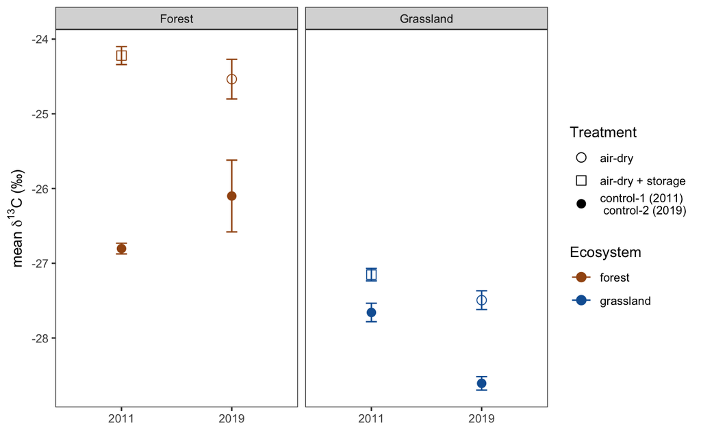

> **Supplemental Fig 3. Time series of control and treatment $\delta$<sup>13</sup>C-CO<sub>2</sub> (Experiments 1 and 2)**

> *Caption:* Filled circles show $\delta$<sup>13</sup>C-CO<sub>2</sub> observed for control samples, while open symbols show $\delta$<sup>13</sup>C-CO<sub>2</sub> observed for treament samples (open squares = air-dry + storage treatment, Experiment 1, 2011; open circles = air-dry only treatment, Experiment 2, 2019). Points are means and error bars show 2x standard error.

*Effect of cumulative respired carbon on <sup>14</sup>C-CO<sub>2</sub>*

We looked at the possible effect of the difference in the amount of carbon respired (mg CO<sub>2</sub>-C g soil C<sup>-1</sup>) on the differences between control and treatment <sup>14</sup>C-CO<sub>2</sub> using a linear regression model, but it was not significant overall. When data from Experiment 1 and Experiment 2 were considered separately, we observed a slight positive trend between the difference in respired carbon and the difference in <sup>14</sup>C-CO<sub>2</sub> within Experiment 2, but it was only marginally significant (p = 0.063).

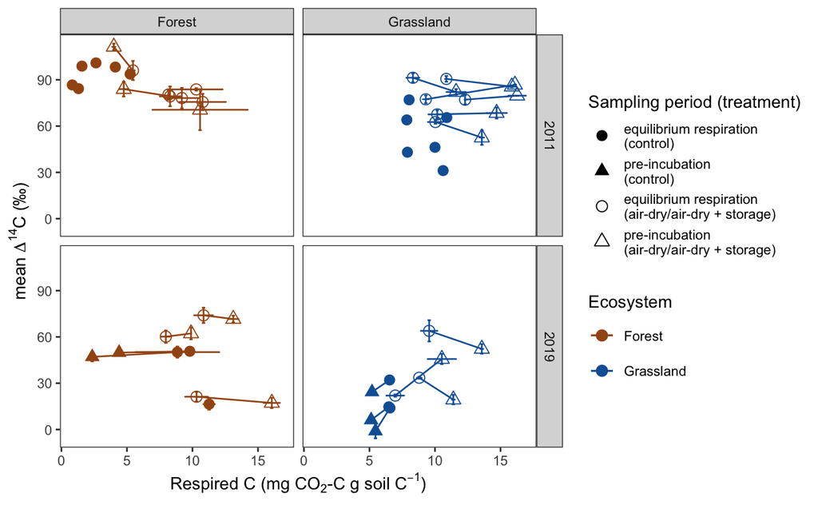

> **Supplementary Fig. 4. Change in <sup>14</sup>C-CO<sub>2</sub> in relation to cumulative soil carbon respired**

> *Caption:* Note that pre-incubation $\Delta$<sup>14</sup>C was not measured for the control-1 samples in 2011. Limits exclude outlier point (HEW22 control-2, pre-incubation) for improved legibility. Points are means, error bars show min and max of duplicate samples.

# Discussion

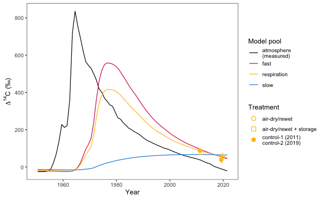

> **Fig 6a. Trajectories of $\Delta$<sup>14</sup>C over time in soil C and respired CO<sub>2</sub> for a 2-pool model fit to the Hainich-Dün forest sites in relation to atmospheric $\Delta$<sup>14</sup>C**

> *Caption:* Modeled curves derived from a two-pool parallel model parameterized with data from Schrumpf et al. (2015): (*k<sub>fast</sub>* = 1/4) and a more slowly cycling pool (*k<sub>slow</sub>* = 1/115). Gold points show observed $\Delta$<sup>14</sup>C-CO<sub>2</sub> from this study. Solid symbols show control samples, open symbols show treatment samples. Atmospheric $\Delta$<sup>14</sup>C data up to the year 2015 are from Graven et al. (2017), while data points beyond 2015 use the extrapolation method from Sierra (2018). All atmospheric radiocarbon data is for the northern hemisphere (zone 2).

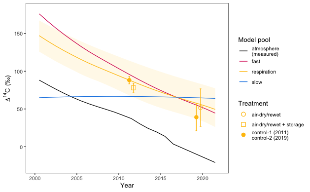

> **Fig 6b. Potential shifts in $\Delta$<sup>14</sup>C of respired CO<sub>2</sub> in response to treatment**

> *Caption:* Zooming in on the study period, we can see that the treatment sample $\Delta$<sup>14</sup>C-CO<sub>2</sub> shifts in the direction of the slowly cycling soil C pool (blue line), indicating increased contribution from this pool to respiration following air-drying and rewetting. Note that the increased contribution from the slow cycling pool leads to depletion in $\Delta$<sup>14</sup>C-CO<sub>2</sub> relative to the controls in 2011, but enrichment in 2019 due to the crossing of the slow and fast cycling pool curves in 2016. Shaded ribbon around the respiration curve shows the model parameterized with the 75th quartile estimates for *k<sub>fast</sub>* (1/7) and *k<sub>slow</sub>* (1/200).

# Change in soil moisture content with moisture adjustment